# Descriptive Statistics

Descriptive statistics are used to provide a brief summary of a data set. Before proceeding with a more detailed analysis (possibly using a bunch of sophisticated statistical techniques) it is vital to have a general understanding of your data. Describing data with simple statistics like the mean, median and standard deviation allows you to put the results of a more detailed analysis into context. They are also useful for communicating data. For example, it’s more useful to tell somebody that the average height of South African men is 1.82 m rather than providing them with a sample of the heights of ten thousand men. Summarising the data picks out the core facts.

For those of you who aren’t in the habit of using maths, this might come as a bit of a shock. But we’ll try to keep things as tame as possible. In the meantime though, perhaps this slice of xkcd will make you feel slightly better.

[figure not shown]

xkcd [#1050](https://xkcd.com/1050/): Forgot Algebra. Read the [explanation](https://www.explainxkcd.com/wiki/index.php/1050:_Forgot_Algebra).

As a general reference on statistical concepts you might like to take a look Matloff (2013). It’s very readable indeed and packed with examples.

Before we get too busy, let’s take a quick look at the data that we’re going to be using for illustrative purposes. We’re going to be looking at the temperature data from the `airquality` data set.

[figure not shown]

I’m a metric guy, so those crazy units make my head hurt. Water freezes at zero and boils at a hundred, right? We’ll fix that.

```r
airquality$Temp = 5 / 9 * (airquality$Temp - 32)
```

[figure not shown]

Now to make things simpler we’ll `attach()` the data frame.

```r
attach(airquality)
```

This adds the `airquality` data frame to R’s search path. As a result, columns within the data frame can be referred to directly. So, for example, instead of doing

```r
min(airquality$Wind)
```

```
[1] 1.7
```

one could simply use

```r
min(Wind)
```

```
[1] 1.7
```

It’s not always a good idea to use `attach()` and it can lead to confusion. But, done with care it can make your code a lot simpler.

# 1 Statistical Inference

We are going to be using a sample to infer the characteristics of a population. Since in general it’s not possible to measure every member of the population, this is normally the only practical (and economic) approach. If the sample is representative of the population then the sample statistics give a reasonable approximation to the corresponding statistics for the population as a whole.

# 2 Mean

The *mean* or *average* gives an indication of the centre of a distribution of numbers. The sample mean for a set of $N$ numbers, $X_1$ to $X_N$, is defined as

$$\hat{\mu} = \frac{1}{N} \sum_{i = 1}^{N} X_i.$$
What’s with the hat on the $\mu$? Well, this is to differentiate between the sample mean, $\hat{\mu}$, and the population mean, $\mu$. Since we generally only have access to a sample from the complete population, it’s the former that we’re normally concerned with.

Let’s look at a concrete example. To find the average temperature in the `airquality` data we sum all the values and then divide by the number of values.

```r
sum(Temp) / length(Temp)
```

```
[1] 25.49
```

You shouldn’t be surprised that R has a native function for doing the same thing.

```r
(mu_temp = mean(Temp))
```

```
[1] 25.49
```

If you take a look at the histogram plot above then you’ll agree that the mean falls close to the central hump in the distribution.

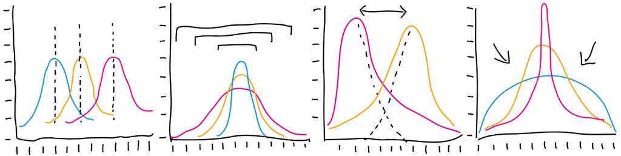

Illustration of the mean, standard deviation, skew and kurtosis. Image borrowed from an article at [www.paypal-engineering.com](https://www.paypal-engineering.com/2016/04/11/statistics-for-software/) which is well worth reading.

# 3 Standard Deviation and Variance

The *standard deviation* describes the width of a distribution, how loosely or tightly the observations are grouped around the mean. Standard deviation is denoted by $\sigma$. The square of the standard deviation, $\sigma^2$, is known as the *variance*. For the same set of $N$ numbers as above, the sample variance is defined as

$$\hat{\sigma}^2 = \frac{1}{N - 1} \sum_{i = 1}^{N} (X_i - \hat{\mu})^2.$$

Let’s calculate the variance directly from our data.

```r
sum((Temp - mu_temp)**2) / (length(Temp) - 1)
```

```
[1] 27.652
```

R has native functions for calculating both the variance and standard deviation.

```r
var(Temp)
```

```
[1] 27.652
```

```r
sd(Temp)
```

```
[1] 5.2585
```

A broader distribution has a larger variance (or standard deviation).

## 3.1 Standard Deviation of the Mean

A common mistake is making a jump from sample mean to population mean. Interpreting the mean height of 10 people you see in Cape Town as the mean height of everyone in Cape Town would be inadvisable. Sure the sample mean is an *estimate* of the population mean, but how good is that estimate? What’s the level of uncertainty?

Suppose that we broke the temperature data up into ten batches and calculated the mean for each of those batches. Would we expect the value to be the same every time? No, of course not. But we would expect the mean for each batch to be somewhere in the vicinity of the mean for the entire data set. Let’s take a look.

First we’ll add a random batch number to our data. Don’t worry about how we do this for the moment.

```r
head(airquality)
```

```
  Ozone Solar.R Wind   Temp Month Day batch
1    41     190  7.4 19.444     5   1     3
2    36     118  8.0 22.222     5   2     4
3    12     149 12.6 23.333     5   3     6
4    18     313 11.5 16.667     5   4    10
5    NA      NA 14.3 13.333     5   5     3
6    28      NA 14.9 18.889     5   6     9
```

Next we calculate the mean and standard deviation of the temperature in each of the batches. Again, don’t fret about how this is done. You’ll learn about this sort of trickery soon enough.

```r
batches
```

```
   batch   mean     sd
1      1 24.111 4.9288
2      2 24.861 5.3083
3      3 25.000 5.7366
4      4 24.575 4.8254
5      5 27.778 4.7173
6      6 24.921 3.4444
7      7 25.494 6.3454
8      8 25.417 5.7534
9      9 27.454 3.6962
10    10 24.074 6.6428
```

The values of mean and standard deviation for each of the batches are similar to what we calculated above for the whole data set. But we also see that there is quite a lot of variability between the batches. To quantify the spread in the batch means we could calculate the standard deviation of the means.

```r
sd(batches$mean)
```

```
[1] 1.2759
```

This gives us an indication of the degree of uncertainty attached to our estimate of the mean. Of course, we don’t want to have to divide our data into batches in order to estimate the standard deviation of the mean. Fortunately there is a more direct way to get there: if $\hat{\sigma}$ is the estimated standard deviation of $N$ values then $\hat{\sigma} / \sqrt{N}$ is the estimated standard deviation of the mean of those values. It’s also known as the *standard error* of the mean.

> … the standard error is the measure of how much random variation we would expect from samples of equal size drawn from the same population.Timothy Urdan (Urdan 2010)

# 4 Quantiles and the Median

To calculate quantiles, first we need to sort our data into ascending order. We then take the sorted data and divide it into bins with the same number of datums in each bin. The quantiles are the numbers at the boundaries of those bins. That sounds more complicated than it actually is. An example will help to illustrate the idea. In R quantiles are found using the `quantile()` function.

```r
quantile(Temp)
```

```
    0%    25%    50%    75%   100%
13.333 22.222 26.111 29.444 36.111
```

The *median* is simply the number that lies in the center of the distribution. It’s the second quartile or fiftieth percentile.

```r
median(Temp)
```

```
[1] 26.111
```

In general, for a fairly symmetric distribution, the median lies close to the mean. So you might think that, since the mean and median are similar, why have both? Although the mean is most commonly used, it does suffer from some problems. The biggest problem is that it is susceptible to bias caused by outliers. The median, on the other hand, is rather robust in the presence of outliers.

It should be noted that the 0% and 100% quantile correspond to the smallest and largest values in the data. There are more direct ways to access these numbers too.

```r
min(Temp)
```

```
[1] 13.333
```

```r
max(Temp)
```

```
[1] 36.111
```

```r
range(Temp)
```

```
[1] 13.333 36.111
```

Finally, because we value data hygiene, we’re going to `detach()` the `airquality` data frame.

```r
detach(airquality)
```

# 5 Exercises

1. Write functions `Mean()` and `Median()` which calulate the mean and median of their arguments.
2. Look at the `precip` and `islands` data in the `datasets` package.
   - Summarise each of these by calculating the mean and median. First use `Mean()` and `Median()`. Compare those results with what you get from `mean()` and `median()`. Are the results the same?
   - For one set of data the mean and median are similar, while for the other they differ substantially. Why? You might find it helpful to look at the distribution of the data as a histogram using `hist()`. You can use `abline()` to superimpose vertical lines for the mean and median.
3. We’re going to be looking at the flights data now.
   - Pick three major U.S. cities.
   - Create a data frame for each city that contains only those flights originating from or arriving at that city.
   - Use `summary()` to compare the quantiles of delay time between the city datasets.
   - Use `boxplot()` to visualise the delay times for all three cities on the same plot. What do you notice? What surprises you about the data, if anything?
4. **Delay Time by Weekday for all NYC Airports:** Construct a visualisation of the distribution of delay times for each NYC airport broken down by weekday. So, for example, it would include the delay times for JFK on Mondays. Subsetting these data might take a bit of work. See if you can find an elegant way to do this?

# Resources

Matloff, Norman. 2013. *From Algorithms to Z-Scores: Probabilistic and Statistical Modeling in Computer Science*. http://tinyurl.com/gu5cfwf.

Reinhart, Alex. 2015. *Statistics Done Wrong*. No Starch Press. http://www.statisticsdonewrong.com/.

Urdan, Timothy C. 2010. *Statistics in Plain English*. Routledge.